# bike-data-analysis

```python
#standard library set up
import numpy as np
import pandas as pd
import matplotlib.pyplot as plt
import matplotlib
import seaborn as sns
import math

%matplotlib inline
```

```python
# I will be making maps and due to the scale, they're going to need to be higher res with Basemap
!yes Y | conda install -c conda-forge basemap-data-hires
from mpl_toolkits.basemap import Basemap
```

[output not shown]

## Load up the data

Starting out by loading up two dataframes. First, the cleaned data for the bike trips. Second, the station data for bikes; while this data is also in the bike dataframe, it's consices and will be useful for some analysis.

```python
path = '/kaggle/input/bikedata/'
bike_df = pd.read_csv(path + 'bike.csv')
station_df = pd.read_csv(path + 'stations.csv')
bike_df.head()
```

|  | duration_sec | start_time | end_time | start_station_id | start_station_name | start_station_latitude | start_station_longitude | end_station_id | end_station_name | end_station_latitude | end_station_longitude | bike_id | user_type |
| --- | --- | --- | --- | --- | --- | --- | --- | --- | --- | --- | --- | --- | --- |
| 0 | 85457 | 2019-07-31 09:25:37.341 | 2019-08-01 09:09:54.600 | 36 | Folsom St at 3rd St | 37.783830 | -122.398870 | 344 | 16th St Depot | 37.766349 | -122.396292 | 3491 | Customer |
| 1 | 53831 | 2019-07-31 18:00:10.294 | 2019-08-01 08:57:21.975 | 139 | Garfield Square (25th St at Harrison St) | 37.751017 | -122.411901 | 133 | Valencia St at 22nd St | 37.755213 | -122.420975 | 2457 | Customer |
| 2 | 33674 | 2019-07-31 22:52:29.791 | 2019-08-01 08:13:44.010 | 155 | Emeryville Public Market | 37.840521 | -122.293528 | 155 | Emeryville Public Market | 37.840521 | -122.293528 | 2750 | Customer |
| 3 | 34546 | 2019-07-31 21:59:34.258 | 2019-08-01 07:35:21.044 | 41 | Golden Gate Ave at Polk St | 37.781270 | -122.418740 | 73 | Pierce St at Haight St | 37.771793 | -122.433708 | 303 | Subscriber |
| 4 | 40244 | 2019-07-31 20:20:37.542 | 2019-08-01 07:31:21.606 | 339 | Jackson St at 11th St | 37.800002 | -122.266438 | 233 | 4th Ave at E 12th St (Temporary Location) | 37.795913 | -122.255547 | 2637 | Subscriber |

```python
station_df.head()
```

|  | station_id | station_name | station_latitude | station_longitude |
| --- | --- | --- | --- | --- |
| 0 | 36 | Folsom St at 3rd St | 37.783830 | -122.398870 |
| 1 | 139 | Garfield Square (25th St at Harrison St) | 37.751017 | -122.411901 |
| 2 | 155 | Emeryville Public Market | 37.840521 | -122.293528 |
| 3 | 41 | Golden Gate Ave at Polk St | 37.781270 | -122.418740 |
| 4 | 339 | Jackson St at 11th St | 37.800002 | -122.266438 |

```python
bike_df['start_time'] = pd.to_datetime(bike_df['start_time'])
bike_df['end_time'] = pd.to_datetime(bike_df['end_time'])
bike_df.dtypes
```

```
duration_sec                        int64
start_time                 datetime64[ns]
end_time                   datetime64[ns]
start_station_id                    int64
start_station_name                 object
start_station_latitude            float64
start_station_longitude           float64
end_station_id                      int64
end_station_name                   object
end_station_latitude              float64
end_station_longitude             float64
bike_id                             int64
user_type                          object
dtype: object
```

Note: in the cleaning process I did a good look at the data so I already have a direction to go for my analysis, hence not a deep look at the types of data, the unique values, etc. here.

## Univariate data

There isn't too much to look at by itself because four columns are geographical data which can't be univariate (latitude by itself can only tell you how closeto the poles or equator the location is and longitude by itself can only tell you what timezone you're in). Here's what I plan to look at:

- Create a histogram of the durration of the rides.
- Create a bar chart for the user types.
- Create bar charts for compairing if the bike started/ended at a station or not.
- Create a violin plot for the number of times a bike is used.
- Create a violin plot for the number of times a bike is checked out and checked in to a station
- Look into usage over time.

### Duration of rides

Here's a look at how long bike rides are.

Note: in the cleaning phase, I noticed two rides that were more than a week long. These I removed these as they were definite outliers (and probably just people forgot to return it... and had a huge late fee).

```python
# start by reexamining the durrations of times.
print('Number 1 second or more: ' + str(bike_df[bike_df['duration_sec'] > 0].shape[0]))
print('Number 1 minute or more: ' + str(bike_df[bike_df['duration_sec'] > 60].shape[0]))
print('Number 1 hour or more: ' + str(bike_df[bike_df['duration_sec'] > 3600].shape[0]))
print('Number 1 day or more: ' + str(bike_df[bike_df['duration_sec'] > 86400].shape[0]))
```

```
Number 1 second or more: 3122228
Number 1 minute or more: 3122017
Number 1 hour or more: 37957
Number 1 day or more: 0
```

Only 1.2% of the data is longer than an hour, and that will majorly skew this to the right. I'm going to just display a histogram from 0 to 5,400 seconds (an hour and a half) for this first look. Then I plan to get a logarithmic histogram to get all the data.

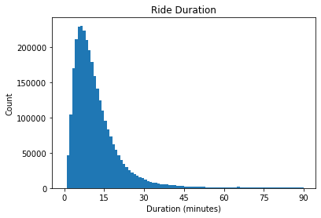

```python
labels = np.array([0, 15, 30, 45, 60, 75, 90])
plt.hist(bike_df['duration_sec'], bins = 90, range = (0, 5400))
plt.title('Ride Duration')
plt.xticks(ticks = labels*60, labels = labels)
plt.xlabel('Duration (minutes)')
plt.ylabel('Count');
```

Time to try something crazy, a log base 60 graph. Why you may ask? Well because 0 is 1 second, 1 is 1 minute and 2 is 1 hour, so let's give it a try.

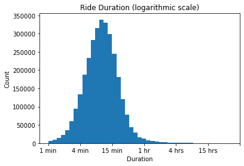

```python
ticks = [1, 1+1/3, 1+2/3, 2, 2+1/3, 2+2/3, 3]
labels = ['1 min', '4 min', '15 min', '1 hr', '4 hrs', '15 hrs', '']
plt.hist(np.log(bike_df['duration_sec'])/np.log(60), bins = 40)
plt.xticks(ticks = ticks, labels = labels)
plt.title('Ride Duration (logarithmic scale)')
plt.ylabel('Count')
plt.xlabel('Duration')
plt.savefig('duration.png');
```

Looks like most rides are between 5 and 20 minutes. There are very few after 1 hour. Thoughts on this: when do the long rides occur in evenings and/or weekends; with all the shorter rides, does this mean the bikes are used for commutes (mass transit to the job)?

### User Types

There are two types of users, subscribers and customers. Okay well they are all customers,but subscribers have paid for more benifits. Let's see who is taking more rides.

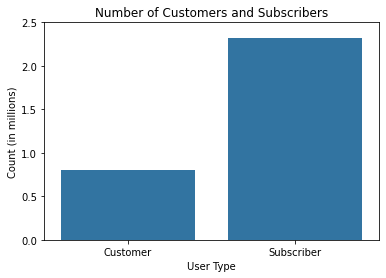

```python
color = sns.color_palette()[0]
sns.countplot(data = bike_df, x = 'user_type', color = color)
plt.title('Number of Customers and Subscribers')
plt.yticks(ticks = [0, 500000, 1000000, 1500000, 2000000, 2500000], labels = [0.0, 0.5, 1.0, 1.5, 2.0, 2.5])
plt.ylabel('Count (in millions)')
plt.xlabel('User Type')
```

Okay it looks like two-thirds to three-fourths of the rides were from subscribers. Not sure why; could be paying that amount makes the subscriber want to use the service more, could be that not enough people know about the service so don't seek it out. I don't think I can get too much more into this with just this data set.

### Station or non-station

Bay Wheels allows users to end there rides and lock the bike away from a station, and other to rent the bike from that non-station. Let's see how common it is for the bike to be picked up or left away from a station.

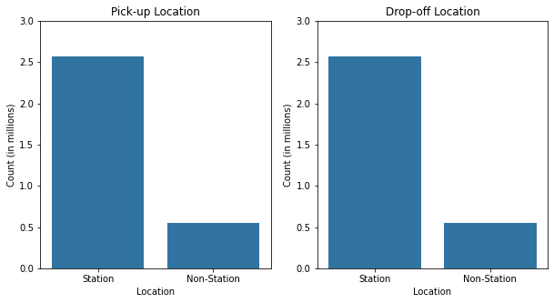

```python
plt.figure(figsize = (10,5))
plt.subplot(1,2,1)
sns.countplot(x = (bike_df['start_station_id'] == -1), color = color)
plt.title('Pick-up Location')
plt.yticks(ticks = [0, 500000, 1000000, 1500000, 2000000, 2500000, 3000000],
           labels = [0.0, 0.5, 1.0, 1.5, 2.0, 2.5, 3.0])
plt.xticks(ticks = [False, True], labels = ['Station', 'Non-Station'])
plt.ylabel('Count (in millions)')
plt.xlabel('Location')

plt.subplot(1,2,2)
sns.countplot(x = (bike_df['end_station_id'] == -1), color = color)
plt.title('Drop-off Location')
plt.yticks(ticks = [0, 500000, 1000000, 1500000, 2000000, 2500000, 3000000],
           labels = [0.0, 0.5, 1.0, 1.5, 2.0, 2.5, 3.0])
plt.xticks(ticks = [False, True], labels = ['Station', 'Non-Station'])
plt.ylabel('Count (in millions)')
plt.xlabel('Location');
```

Okay only about one-sixth of the bikes are left off or picked up somewhere other than a station.

### Times a Bike is Used

There is a bike id. Let's see if there's anything that can be said about how often an individual bike was used.

```python
bike_use_count = bike_df['bike_id'].value_counts()
bike_use_count.describe()
```

```
count    13658.000000
mean       228.600674
std        171.952682
min          1.000000
25%         93.000000
50%        200.000000
75%        315.000000
max        926.000000
Name: bike_id, dtype: float64
```

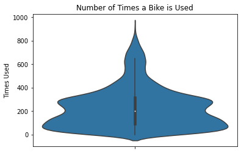

```python
sns.violinplot(y = bike_use_count)
plt.title('Number of Times a Bike is Used')
plt.ylabel('Times Used')
```

The median is 200 uses and most of the bikes have been used less than 400 times. But a few have been used almost a thousand times.

### How Often is a Station used.

There are 449 stations. Let's see how frequently they are used.

```python
start_station_count = bike_df[bike_df['start_station_id'] > 0]['start_station_id'].value_counts()
end_station_count = bike_df[bike_df['end_station_id'] > 0]['end_station_id'].value_counts()
start_station_count.describe(), end_station_count.describe()
```

```
(count      449.000000
 mean      5730.120267
 std       7073.666043
 min          4.000000
 25%        953.000000
 50%       3251.000000
 75%       8531.000000
 max      47246.000000
 Name: start_station_id, dtype: float64,
 count      449.000000
 mean      5727.055679
 std       7895.247739
 min          1.000000
 25%        893.000000
 50%       3064.000000
 75%       7863.000000
 max      59843.000000
 Name: end_station_id, dtype: float64)
```

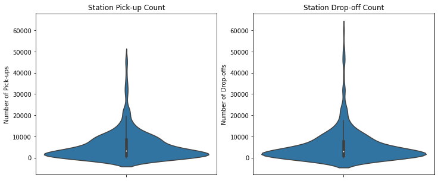

```python
plt.figure(figsize = (12,5))
plt.subplot(1,2,1)
sns.violinplot(y = start_station_count)
plt.title('Station Pick-up Count')
plt.ylabel('Number of Pick-ups')
plt.ylim((-8000,68000))

plt.subplot(1,2,2)
sns.violinplot(y = end_station_count)
plt.title('Station Drop-off Count')
plt.ylabel('Number of Drop-offs')
plt.ylim((-8000,68000));
```

Looks like most stations are used less than 10,000 times, but a few stations are really popular (that might be interesting to look into more).

### Usage and Time

It's now time to look into usage over time. What is the trend over time (note: due to Covid-19 there will probably be a sharp drop off near the end)? What day of the week is most popular? What time period is most popular?

So much to look at let's dive in.

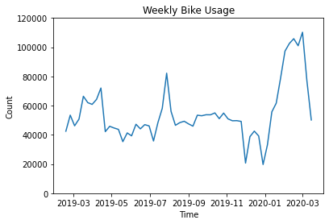

```python
start_times = pd.Series(data = 1, index = bike_df['start_time'])
plt.plot(start_times.resample('W').count())
plt.title('Weekly Bike Usage')
plt.ylim(0,120000)
plt.ylabel('Count')
plt.xlabel('Time');
```

Looks like there were some weekly spikes in late March 2019 and April 2019, a large spike around the end of July beginning of August 2019, a large drop in November and December (probably Thanksgiving and Christmas weeks), doing very well at the beginning of 2020, and then a sudden downturn in March (relating to Covid-19 no doubt).

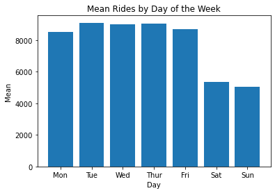

```python
day_count = start_times.resample('D').count()
day_of_week_mean = day_count.groupby(day_count.index.dayofweek).mean()
plt.bar(day_of_week_mean.index, day_of_week_mean)
plt.xticks(ticks = [0, 1, 2, 3, 4, 5, 6], labels = ['Mon', 'Tue', 'Wed', 'Thur', 'Fri', 'Sat', 'Sun'])
plt.title('Mean Rides by Day of the Week')
plt.xlabel('Day')
plt.ylabel('Mean');
```

Looks like on average, the weekdays get more usage than the weekend.

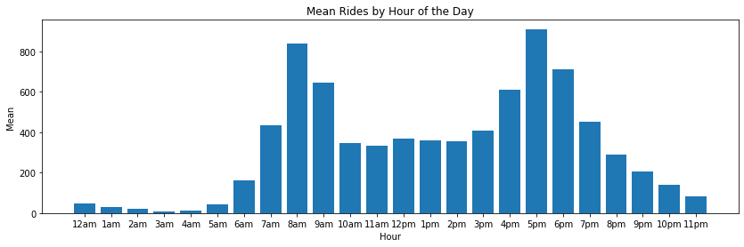

```python
hour_count = start_times.resample('H').count()
hour_of_day_mean = hour_count.groupby(hour_count.index.time).mean()

plt.figure(figsize = (14,4))
plt.bar(['12am', '1am', '2am', '3am', '4am', '5am', '6am', '7am',
        '8am', '9am', '10am', '11am', '12pm', '1pm', '2pm', '3pm',
        '4pm', '5pm', '6pm', '7pm', '8pm', '9pm', '10pm', '11pm'], hour_of_day_mean)
plt.title('Mean Rides by Hour of the Day')
plt.xlabel('Hour')
plt.ylabel('Mean');
```

By hour, that looks very much like a golden gate bridge. Joking a side, there are peeks of the data at the commute times. It might be different between weekdays and weekends, but that's more bivariate data.

## Bivariate Data

Now let's look at the relation between two variables.

- Most important, create a scatter plot on a map to show where the stations are at.
- Create a heat map like scatter plot for the popularity of the stations on a map (color of the dots on a scale).
- Create a heat map superimposed on a map to show locations of non-station locations.
- Look into hourly usage for weekdays and weekends.
- Create a multibar chart for user type and if they're picking up or dropping off bike at stations or not. I'll probably make two, one just as raw numbers and one as proportions.
- Do time analysis on user type over time.
- Look at the duration of rides in relationship to times of day and day of the week.

### Station locations

Now, I'm going to figure out how to get a map background for a scatter plot and then create a map of the station locations. This will be helpful as the latitude and longitude with out reference to a map (a typical scatter plot will have issues with say the San Francisco Bay).

Because I had to figure out how to work with maps, I've already figured somethings out. In particular, I know I'm going to have to get a function to get the basics of the plots (so I don't have to keep redoing it).

```python
# This gets the basics for the maps I'm going to use. The box coordinates is a list of ordered pairs for
# lower left and upper right. I'm going to need some city level maps so I have rhe resolution at full,
# but for the entire bay area, I'm going to be using high.
def map_plot(box_coord, res = 'f'):
    m = Basemap(projection='cyl', llcrnrlat = box_coord[0][0], urcrnrlat = box_coord[1][0],
                llcrnrlon = box_coord[0][1], urcrnrlon = box_coord[1][1], resolution=res)
    m.fillcontinents(zorder = 0)
    m.drawmapboundary()
    m.drawcoastlines()
    return m
```

```python
# Getting the lower left and upper right for the bay area (min and max coordinate for the table)
# I'm using the end points of the rides as I would assume that it would be the furthest appart
# I'm adding a little bit of standard deviation so no points are on the end
bay_coord= [(bike_df['end_station_latitude'].min() - 0.2* bike_df['end_station_latitude'].std(),
              bike_df['end_station_longitude'].min() - 0.2* bike_df['end_station_longitude'].std()),
             (bike_df['end_station_latitude'].max() + 0.2* bike_df['end_station_latitude'].std(),
             bike_df['end_station_longitude'].max() + 0.2* bike_df['end_station_longitude'].std())]
bay_coord
```

```
[(37.20374841764074, -122.60167115054598),
 (38.018293582359256, -121.70770751605401)]
```

First let's look at the stations over the bay area.

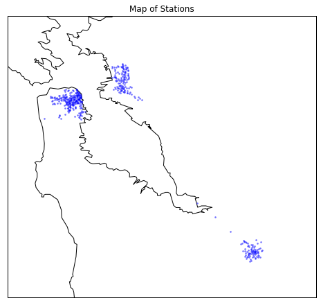

```python
plt.figure(figsize = (8,8))
bay_map = map_plot(bay_coord, res = 'h')
bay_map.scatter(station_df['station_longitude'], station_df['station_latitude'],
          latlon = True, color = 'b', zorder = 10, s = 3, alpha = 0.4)
plt.title('Map of Stations')
```

There are 3 clusters of stations. My wife (a bay area native) identified them as San Francisco, Oakland, and San Jose (and I confirmed via the mean of station locations and google maps). Let's isolate those clusters.

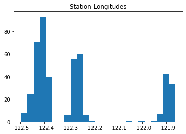

```python
plt.hist(station_df['station_longitude'], bins = 25)
plt.title('Station Longitudes')
```

There are very clear clusters; from left to right, that's San Francisco, Oakland, and San Jose. I'm temporarily breaking station dataframe so I can look at these cities a little more so I can get box coordinates for them.

```python
#get the min, max, and center coordinates for each region
def min_max_cen (df):
    min_coord = (df['station_latitude'].min() - df['station_latitude'].std(),
                 df['station_longitude'].min() - df['station_longitude'].std())
    max_coord = (df['station_latitude'].max() + df['station_latitude'].std(),
                 df['station_longitude'].max() + df['station_longitude'].std())
    center_coord = ((max_coord[0]+min_coord[0])/2, (max_coord[1]+min_coord[1])/2)
    return min_coord, max_coord, center_coord

sf_st_df = station_df[station_df['station_longitude'] <= -122.35]
oak_st_df = station_df[(station_df['station_longitude'] > -122.35)&(station_df['station_longitude'] <= -122.1)]
sj_st_df = station_df[station_df['station_longitude'] > -122.1]

sf_min, sf_max, sf_cen = min_max_cen(sf_st_df)
oak_min, oak_max, oak_cen = min_max_cen(oak_st_df)
sj_min, sj_max, sj_cen = min_max_cen(sj_st_df)

sf_cen, oak_cen, sj_cen
```

```
((37.7615035, -122.4360125),
 (37.827726999999996, -122.25631150000001),
 (37.392526000000004, -121.9582865))
```

```python
# Just using the min and max as lower and upper bounds as boundrys, the boxes are not a uniform size.
# To do that I'm going to use the min and max of the of the bounding boxes for all of the boxes.
# And that was a bit rambling...
lat_max = max([sf_max[0] - sf_min[0], oak_max[0] - oak_min[0], sj_max[0] - sj_min[0]])
lon_max = max([sf_max[1] - sf_min[1], oak_max[1] - oak_min[1], sj_max[1] - sj_min[1]])

sf_coord = [(sf_cen[0] - lat_max/2, sf_cen[1] - lon_max/2), (sf_cen[0] + lat_max/2, sf_cen[1] + lon_max/2)]
oak_coord = [(oak_cen[0] - lat_max/2, oak_cen[1] - lon_max/2), (oak_cen[0] + lat_max/2, oak_cen[1] + lon_max/2)]
sj_coord = [(sj_cen[0] - lat_max/2, sj_cen[1] - lon_max/2), (sj_cen[0] + lat_max/2, sj_cen[1] + lon_max/2)]

sf_coord, oak_coord, sj_coord, lat_max, lon_max
```

```
([(37.654008077384624, -122.55603362850982),
  (37.86899892261538, -122.31599137149018)],
 [(37.72023157738462, -122.37633262850983),
  (37.935222422615375, -122.13629037149019)],
 [(37.285030577384624, -122.07830762850982),
  (37.50002142261538, -121.83826537149018)],
 0.2149908452307585,
 0.24004225701963833)
```

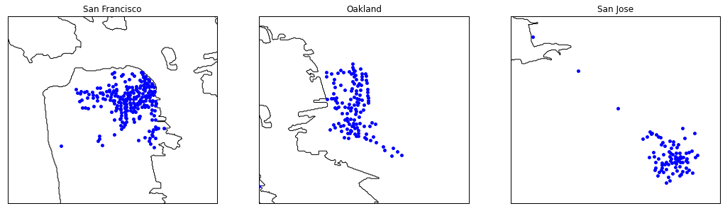

```python
cities = [(sf_coord,'San Francisco'),(oak_coord, 'Oakland'),(sj_coord, 'San Jose')]

# Now that I have that, let's see those maps.
plt.figure(figsize = (18, 6))

for i in range(len(cities)):
    plt.subplot(1,3,i + 1)
    city_map = map_plot(cities[i][0])
    city_map.scatter(station_df['station_longitude'], station_df['station_latitude'],
              latlon = True, color = 'b', zorder = 10, s = 15)
    plt.title(cities[i][1])
```

It looks like the largest density of stations is in San Francisco, Oakland has the widest spread, and there are three outliers in the San Jose area.

### Station Popularity

There are a lot of stations, let see which ones are used most frequently.

```python
# So I can do a heat map, I need to get a count of when the station is used. I will use the start
# as the popularity as I think that will be the most accurate.
station_count = []

for row in station_df.values:
    station_count.append(len(bike_df[bike_df['start_station_id'] == row[0]].index))

station_df['count'] = station_count
station_df.head()
```

|  | station_id | station_name | station_latitude | station_longitude | count |
| --- | --- | --- | --- | --- | --- |
| 0 | 36 | Folsom St at 3rd St | 37.783830 | -122.398870 | 13095 |
| 1 | 139 | Garfield Square (25th St at Harrison St) | 37.751017 | -122.411901 | 9678 |
| 2 | 155 | Emeryville Public Market | 37.840521 | -122.293528 | 2360 |
| 3 | 41 | Golden Gate Ave at Polk St | 37.781270 | -122.418740 | 8603 |
| 4 | 339 | Jackson St at 11th St | 37.800002 | -122.266438 | 1980 |

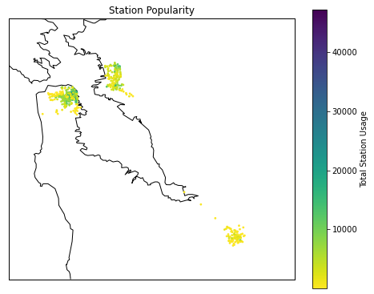

```python
plt.figure(figsize = (8,8))
bay_map = map_plot(bay_coord, res = 'h')
bay_map.scatter(station_df['station_longitude'], station_df['station_latitude'], c = station_df['count'],
          latlon = True, zorder = 10, s = 3, cmap = 'viridis_r')
plt.title('Station Popularity')
plt.colorbar(label = 'Total Station Usage', shrink = 0.8)
plt.savefig('bay_stations.png');
```

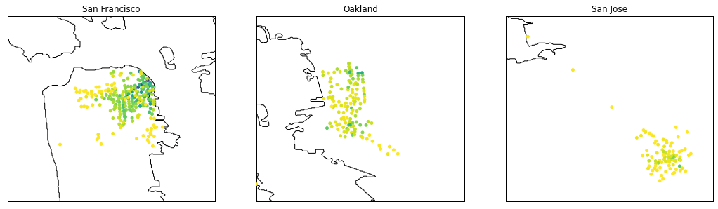

```python
fig = plt.figure(figsize = (18,6))

for i in range(3):
    ax = fig.add_subplot(1, 3, i + 1)
    city_map = map_plot(cities[i][0])
    city_map.scatter(station_df['station_longitude'], station_df['station_latitude'], c = station_df['count'],
              latlon = True, zorder = 10, s = 15, cmap = 'viridis_r')
    plt.title(cities[i][1])
plt.savefig('city_stations.png');
```

It looks like the most popular stations are in northeast San Francisco, and San Jose isn't very popular yet

### Non-Station Locations

Let's now look at the locations that the bike go when left not at a station.

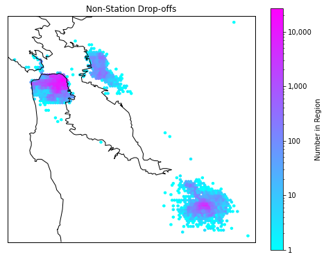

```python
plt.figure(figsize = (8,8))
bay_map = map_plot(bay_coord, res = 'h')
bay_map.hexbin(bike_df[bike_df['end_station_id'] == -1]['end_station_longitude'],
              bike_df[bike_df['end_station_id'] == -1]['end_station_latitude'],
               cmap = 'cool', mincnt = 1, bins = 'log')
plt.title('Non-Station Drop-offs')
cb = plt.colorbar(label = 'Number in Region', shrink = 0.8)
cb.set_ticks([1, 10, 100, 1000, 10000])
cb.set_ticklabels(['1', '10', '100', '1,000', '10,000'])
plt.savefig('bay_nonstations.png');
```

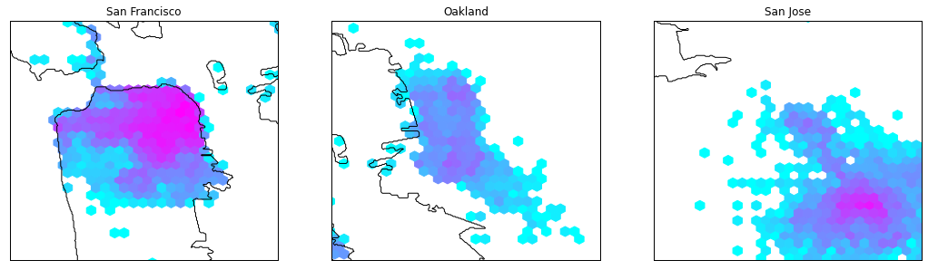

```python
fig = plt.figure(figsize = (18,6))

for i in range(3):
    ax = fig.add_subplot(1, 3, i + 1)
    city_map = map_plot(cities[i][0])
    city_map.hexbin(bike_df[bike_df['end_station_id'] == -1]['end_station_longitude'],
                  bike_df[bike_df['end_station_id'] == -1]['end_station_latitude'],
                   cmap = 'cool', mincnt = 1, bins = 'log')
    plt.title(cities[i][1])
plt.savefig('city_nonstations.png');
```

For the most part the bikes were left near stations. but there are few that were left elsewhere (across and on the Golden Gate Bridge, on an island between San Francisco and Oakland, and one in the north-east corner of the map.

### Usage by Time between Weekday and Weekends

We saw previously that the usage averaged higher durring rush hour. But does this hold for the weekends as well as weekdays (or possibly it happens only on the weekend, but probably not).

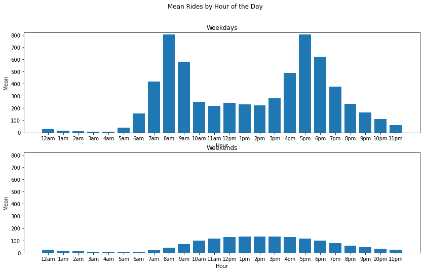

```python
def hourly_plot (times):
    hour_count = times.resample('H').count()
    hour_of_day_mean = hour_count.groupby(hour_count.index.time).mean()

    p = plt.bar(['12am', '1am', '2am', '3am', '4am', '5am', '6am', '7am',
            '8am', '9am', '10am', '11am', '12pm', '1pm', '2pm', '3pm',
            '4pm', '5pm', '6pm', '7pm', '8pm', '9pm', '10pm', '11pm'], hour_of_day_mean)
    px = plt.xlabel('Hour')
    py = plt.ylabel('Mean')
    return p, px, py

start_times_weekday = pd.Series(data = 1, index = bike_df[bike_df['start_time'].dt.weekday < 5]['start_time'])
start_times_weekend = pd.Series(data = 1, index = bike_df[bike_df['start_time'].dt.weekday > 4]['start_time'])

plt.figure(figsize = (14,8))
plt.suptitle('Mean Rides by Hour of the Day')

plt.subplot(2,1,1)
plot1, x1, y1 = hourly_plot(start_times_weekday)
plt.title('Weekdays')
plt.ylim(0, 820)

plt.subplot(2,1,2)
plot2, x2, y2 = hourly_plot(start_times_weekend)
plt.title('Weekends')
plt.ylim(0, 820)

plt.savefig('hourly_counts.png');
```

It does look like a very different shape for the weekend then the weekday. It also emphisies that the weekend has a much lower ridership than the weekdays.

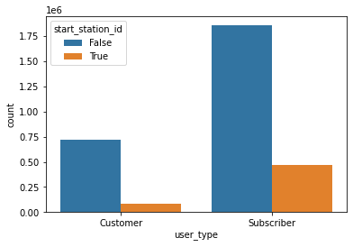

```python
sns.countplot(x = bike_df['user_type'], hue = (bike_df['start_station_id'] == -1))
```

### User Types over Time

Let's look at if there an increase/decrease over time for the user types that's different than the overall trend.

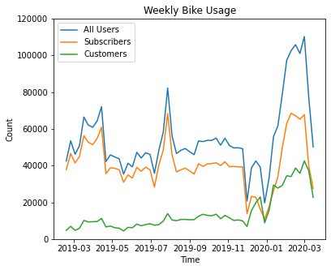

```python
start_times = pd.Series(data = 1, index = bike_df['start_time'])
subs_times = pd.Series(data = 1, index = bike_df[bike_df['user_type'] == 'Subscriber']['start_time'])
cust_times = pd.Series(data = 1, index = bike_df[bike_df['user_type'] == 'Customer']['start_time'])
plt.figure(figsize = (6,5))
plt.plot(start_times.resample('W').count(), '-', label = 'All Users')
plt.plot(subs_times.resample('W').count(), '-', label = 'Subscribers')
plt.plot(cust_times.resample('W').count(), '-', label = 'Customers')
plt.title('Weekly Bike Usage')
plt.ylim(0,120000)
plt.ylabel('Count')
plt.xlabel('Time')
plt.legend()
plt.savefig('usage.png');
```

For the majority of 2019, it looks like the customers and subscribers both keep the same proportionality to the overall trend. At the end of 2019/start of 2020 the customer's started increasing at a greater rate and the two user types seem change the proportionality to the overall curve. Of course then 2020, became wierd.

### Duration and Days of the Week and Time of Day

I want to look at the average durations of the rides depending on the times and days

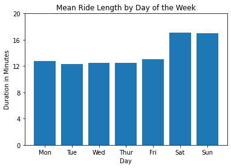

```python
start_times = pd.Series(data = bike_df['duration_sec'])
start_times.index = bike_df['start_time']
day_sum = start_times.resample('D').sum()
day_count = start_times.resample('D').count()
day_of_week_mean = day_sum.groupby(day_sum.index.dayofweek).sum()/day_count.groupby(day_count.index.dayofweek).sum()
plt.bar(day_of_week_mean.index, day_of_week_mean)
plt.xticks(ticks = [0, 1, 2, 3, 4, 5, 6], labels = ['Mon', 'Tue', 'Wed', 'Thur', 'Fri', 'Sat', 'Sun'])
plt.yticks(ticks = [0, 240, 480, 720, 960, 1200], labels = ['0', '4', '8', '12', '16', '20'])
plt.title('Mean Ride Length by Day of the Week')
plt.xlabel('Day')
plt.ylabel('Duration in Minutes');
#start_times
```

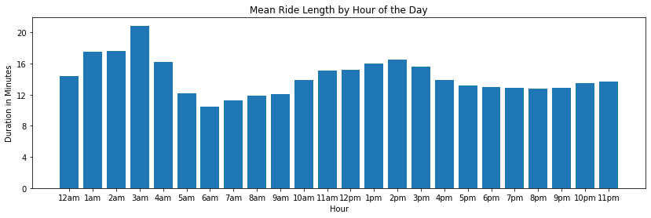

```python
hour_sum = start_times.resample('H').sum()
hour_count = start_times.resample('H').count()
hour_of_day_mean = hour_sum.groupby(hour_count.index.time).sum()/hour_count.groupby(hour_count.index.time).sum()

plt.figure(figsize = (14,4))
plt.bar(['12am', '1am', '2am', '3am', '4am', '5am', '6am', '7am',
        '8am', '9am', '10am', '11am', '12pm', '1pm', '2pm', '3pm',
        '4pm', '5pm', '6pm', '7pm', '8pm', '9pm', '10pm', '11pm'], hour_of_day_mean)
plt.yticks(ticks = [0, 240, 480, 720, 960, 1200], labels = ['0', '4', '8', '12', '16', '20'])
plt.title('Mean Ride Length by Hour of the Day')
plt.xlabel('Hour')
plt.ylabel('Duration in Minutes');
```

It appears that bike rides are longer on the weekends (probably riding for pleasure), and late nights (probably after public transportation has shut down for the night)

## Multivariate Data

Time to look at more data together. Here's what I'm planning to look at.

### Stations by Time

```python
# Get columns for these counts
time_intervals = ['12a-3a', '3a-6a', '6a-9a', '9a-12p', '12p-3p', '3p-6p', '6p-9p', '9p-12a']
for interval in time_intervals:
    station_df[interval] = 0

station_df.head()
```

|  | station_id | station_name | station_latitude | station_longitude | count | 12a-3a | 3a-6a | 6a-9a | 9a-12p | 12p-3p | 3p-6p | 6p-9p | 9p-12a |
| --- | --- | --- | --- | --- | --- | --- | --- | --- | --- | --- | --- | --- | --- |
| 0 | 36 | Folsom St at 3rd St | 37.783830 | -122.398870 | 13095 | 0 | 0 | 0 | 0 | 0 | 0 | 0 | 0 |
| 1 | 139 | Garfield Square (25th St at Harrison St) | 37.751017 | -122.411901 | 9678 | 0 | 0 | 0 | 0 | 0 | 0 | 0 | 0 |
| 2 | 155 | Emeryville Public Market | 37.840521 | -122.293528 | 2360 | 0 | 0 | 0 | 0 | 0 | 0 | 0 | 0 |
| 3 | 41 | Golden Gate Ave at Polk St | 37.781270 | -122.418740 | 8603 | 0 | 0 | 0 | 0 | 0 | 0 | 0 | 0 |
| 4 | 339 | Jackson St at 11th St | 37.800002 | -122.266438 | 1980 | 0 | 0 | 0 | 0 | 0 | 0 | 0 | 0 |

```python
station_times = bike_df.loc[:,['start_time','start_station_id']]
hour = station_times['start_time'].dt.hour
station_times['hour'] = hour

station_times.head()
```

|  | start_time | start_station_id | hour |
| --- | --- | --- | --- |
| 0 | 2019-07-31 09:25:37.341 | 36 | 9 |
| 1 | 2019-07-31 18:00:10.294 | 139 | 18 |
| 2 | 2019-07-31 22:52:29.791 | 155 | 22 |
| 3 | 2019-07-31 21:59:34.258 | 41 | 21 |
| 4 | 2019-07-31 20:20:37.542 | 339 | 20 |

```python
for id in station_df['station_id']:
    for i in range(8):
        count = station_times[(station_times['start_station_id'] == id) & (station_times['hour'] >= (3*i))
                             & (station_times['hour'] < (3*i +2))]['hour'].count()
        station_df.at[station_df[station_df['station_id'] == id].index[0], time_intervals[i]] = count

station_df.head()
```

|  | station_id | station_name | station_latitude | station_longitude | count | 12a-3a | 3a-6a | 6a-9a | 9a-12p | 12p-3p | 3p-6p | 6p-9p | 9p-12a |
| --- | --- | --- | --- | --- | --- | --- | --- | --- | --- | --- | --- | --- | --- |
| 0 | 36 | Folsom St at 3rd St | 37.783830 | -122.398870 | 13095 | 100 | 32 | 757 | 1680 | 1135 | 1509 | 2380 | 700 |
| 1 | 139 | Garfield Square (25th St at Harrison St) | 37.751017 | -122.411901 | 9678 | 38 | 10 | 1076 | 1720 | 799 | 801 | 1042 | 290 |
| 2 | 155 | Emeryville Public Market | 37.840521 | -122.293528 | 2360 | 19 | 48 | 87 | 218 | 314 | 387 | 404 | 135 |
| 3 | 41 | Golden Gate Ave at Polk St | 37.781270 | -122.418740 | 8603 | 68 | 32 | 412 | 1490 | 1053 | 1099 | 1008 | 255 |
| 4 | 339 | Jackson St at 11th St | 37.800002 | -122.266438 | 1980 | 62 | 2 | 196 | 167 | 186 | 282 | 275 | 80 |

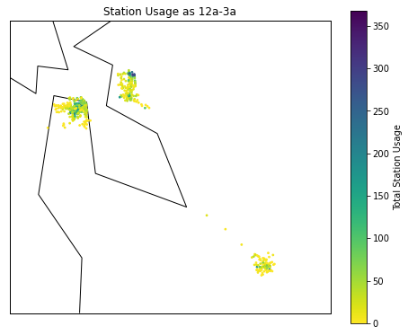

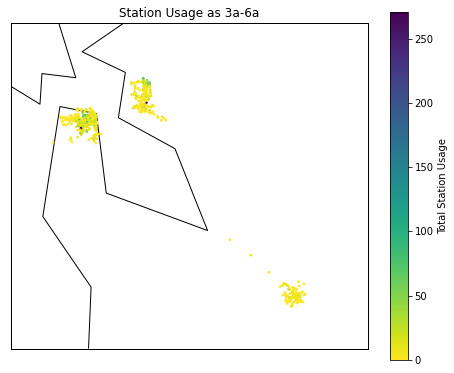

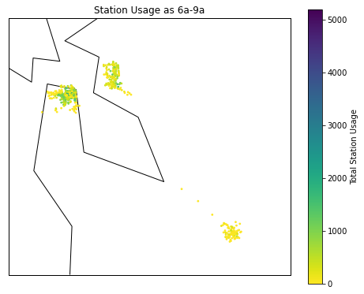

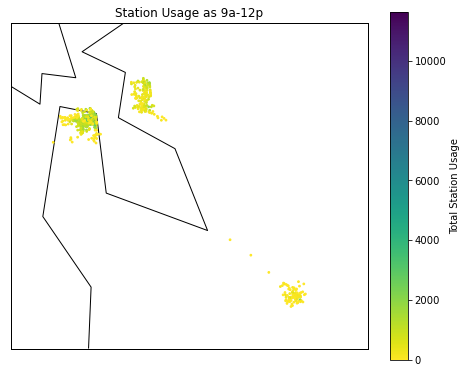

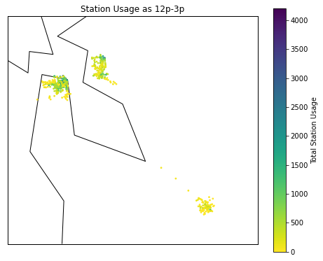

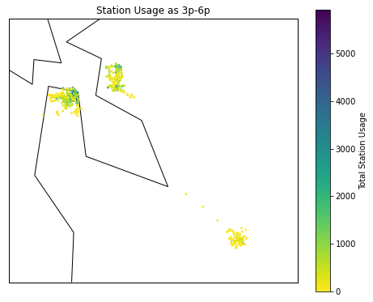

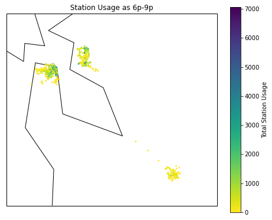

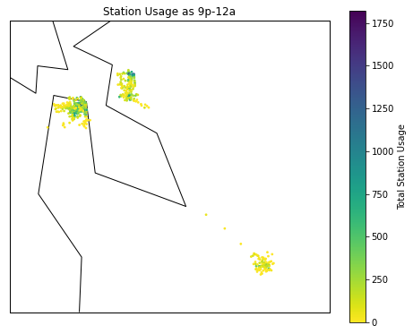

```python
for i in time_intervals:
    plt.figure(figsize = (8,8))
    bay_map = map_plot(bay_coord, res = 'l')
    bay_map.scatter(station_df['station_longitude'], station_df['station_latitude'], c = station_df[i],
              latlon = True, zorder = 10, s = 3, cmap = 'viridis_r')
    plt.title('Station Usage as ' + i)
    plt.colorbar(label = 'Total Station Usage', shrink = 0.8)
    plt.show()
```